# The Advantages of Energy Regression for Mediation

```r
# Optional: enable parallel cross-fitting
library(future)
plan(multisession)
```

## Introduction

Energy regression (`engression`) learns the **full conditional distribution** $P(Y|X)$, whereas standard mediation tools like `crumble` (via `SuperLearner`) typically target only the **conditional mean** $E[Y|X]$. This vignette demonstrates scenarios where this difference matters for obtaining correct causal estimates, comparing `dma` against `crumble` with a GLM learner on each scenario.

### Mediation decomposition

In natural effects mediation, we decompose the ATE into:

- **NDE** (Natural Direct Effect): $E[Y(1, M(0))] - E[Y(0, M(0))]$ — effect of treatment holding mediator at control level
- **NIE** (Natural Indirect Effect): $E[Y(1, M(1))] - E[Y(1, M(0))]$ — effect of treatment through the mediator only
- **ATE**: $E[Y(1, M(1))] - E[Y(0, M(0))]$ = NDE + NIE

Standard methods estimate these as **mean** contrasts. But the full potential outcome *distributions* $P(Y(a, M(a')))$ reveal much more: how treatment reshapes the entire outcome distribution, not just its center.

## 1. The Bimodal Mediator Challenge

In many settings, a behavior (the mediator) is bimodal: individuals are either “high” or “low,” but rarely at the average.

**Scenario**:

- $A=0 \implies M \sim N(0, 0.5^2)$
- $A=1 \implies M$ is a mixture: $50\% \sim N(-2, 0.5^2)$ and $50\% \sim N(2, 0.5^2)$
- $Y = M^2 + \epsilon$ (no direct effect of $A$ on $Y$)
- **Note**: $E[M|A=1] = 0 = E[M|A=0]$, so mean-based methods see no mediator shift
- **True NIE**: $E[M^2|A=1] - E[M^2|A=0] = 4.25 - 0.25 = \mathbf{4.0}$

```r
library(dma)
library(crumble)

set.seed(123)
n <- 1000
A <- rbinom(n, 1, 0.5)
M <- ifelse(A == 0, rnorm(n, 0, 0.5),
            ifelse(runif(n) > 0.5, rnorm(n, -2, 0.5), rnorm(n, 2, 0.5)))
Y <- M^2 + rnorm(n, 0, 0.5)
data <- data.frame(A, M, Y, W = rnorm(n))

d0 <- \(data, trt) 0
d1 <- \(data, trt) 1

# dma (Distributional)
res_dma <- dma(
  data = data, trt = "A", outcome = "Y", mediators = "M", covar = "W",
  d0 = d0, d1 = d1, effect = "N",
  control = dma_control(crossfit_folds = 1L, num_epochs = 200L, riesz_epochs = 50L)
)

# crumble (Mean-based GLM)
res_crumble <- crumble(
  data = data, trt = "A", outcome = "Y", mediators = "M", covar = "W",
  d0 = d0, d1 = d1, effect = "N",
  learners = "glm",
  control = crumble_control(crossfit_folds = 1L, epochs = 20L)
)
```

| Estimand | Truth | dma | crumble (GLM) |
| --- | --- | --- | --- |
| NIE | 4.0 | 4.992 | -0.240 |

### Distributional decomposition

```r
set.seed(42)
n_o <- 10000
eps <- rnorm(n_o, 0, 0.5)

# Draw mediators under each regime
M_ctrl <- rnorm(n_o, 0, 0.5)                    # M(0)
M_trt  <- ifelse(runif(n_o) > 0.5,              # M(1)
                 rnorm(n_o, -2, 0.5), rnorm(n_o, 2, 0.5))

# Four potential outcomes: Y = M^2 + eps (no direct A effect)
Y00 <- M_ctrl^2 + eps   # Y(0, M(0))
Y11 <- M_trt^2  + eps   # Y(1, M(1))
Y10 <- M_ctrl^2 + eps   # Y(1, M(0)) = Y(0, M(0)) since no direct effect
Y01 <- M_trt^2  + eps   # Y(0, M(1)) = Y(1, M(1)) since no direct effect

knitr::kable(print_decomposition(Y00, Y11, Y10, Y01), align = "lr")
```

| Effect | Value |
| --- | --- |
| ATE = E[Y(1,M(1))] - E[Y(0,M(0))] | 3.999 |
| NDE = E[Y(1,M(0))] - E[Y(0,M(0))] | 0.000 |
| NIE = E[Y(1,M(1))] - E[Y(1,M(0))] | 3.999 |

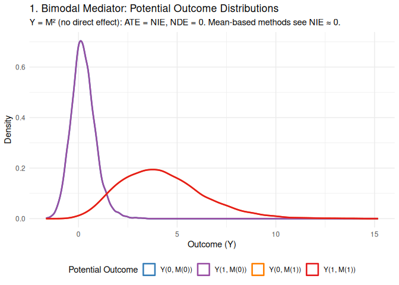

```r
plot_po_distributions(Y00, Y11, Y10, Y01,
  title = "1. Bimodal Mediator: Potential Outcome Distributions",
  subtitle = "Y = M² (no direct effect): ATE = NIE, NDE = 0. Mean-based methods see NIE ≈ 0.")
```

**Key insight**: Because $A$ has no direct effect on $Y$, $Y(1,M(0)) = Y(0,M(0))$ and $Y(0,M(1)) = Y(1,M(1))$ — the NDE is zero and the entire ATE flows through the mediator. The treated and indirect-only distributions are identical: a heavy right tail from $M^2 \approx 4$. A mean-based learner that only sees $E[M|A=0] = E[M|A=1] = 0$ concludes NIE $\approx 0$.

## 2. Heteroskedasticity (Variance as Signal)

Treatment often changes the **variance** or **spread** of a behavior without shifting its mean.

**Scenario**:

- $M|A=0 \sim N(0, 1^2)$, $M|A=1 \sim N(0, 3^2)$
- $Y = M^2 + \epsilon$ (no direct effect)
- **True NIE**: $E[M^2|A=1] - E[M^2|A=0] = 9 - 1 = \mathbf{8.0}$

```r
set.seed(123)
n <- 1000
A <- rbinom(n, 1, 0.5)
M <- rnorm(n, 0, sd = ifelse(A == 0, 1, 3))
Y <- M^2 + rnorm(n, 0, 0.5)
data <- data.frame(A, M, Y, W = rnorm(n))

# dma
res_dma_het <- dma(
  data = data, trt = "A", outcome = "Y", mediators = "M", covar = "W",
  d0 = d0, d1 = d1, effect = "N",
  control = dma_control(crossfit_folds = 1L, num_epochs = 200L, riesz_epochs = 50L)
)

# crumble
res_crumble_het <- crumble(
  data = data, trt = "A", outcome = "Y", mediators = "M", covar = "W",
  d0 = d0, d1 = d1, effect = "N",
  learners = "glm",
  control = crumble_control(crossfit_folds = 1L, epochs = 20L)
)
```

| Estimand | Truth | dma | crumble (GLM) |
| --- | --- | --- | --- |
| NIE | 8.0 | 7.721 | -0.137 |

### Distributional decomposition

```r
set.seed(42)
n_o <- 10000
eps <- rnorm(n_o, 0, 0.5)

M_ctrl <- rnorm(n_o, 0, 1)   # M(0): sd = 1
M_trt  <- rnorm(n_o, 0, 3)   # M(1): sd = 3

# Y = M² + eps (no direct effect)
Y00 <- M_ctrl^2 + eps
Y11 <- M_trt^2  + eps
Y10 <- M_ctrl^2 + eps  # = Y00
Y01 <- M_trt^2  + eps  # = Y11

knitr::kable(print_decomposition(Y00, Y11, Y10, Y01), align = "lr")
```

| Effect | Value |
| --- | --- |
| ATE = E[Y(1,M(1))] - E[Y(0,M(0))] | 8.238 |
| NDE = E[Y(1,M(0))] - E[Y(0,M(0))] | 0.000 |
| NIE = E[Y(1,M(1))] - E[Y(1,M(0))] | 8.238 |

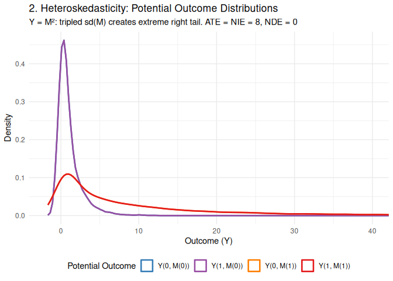

```r
plot_po_distributions(Y00, Y11, Y10, Y01,
  title = "2. Heteroskedasticity: Potential Outcome Distributions",
  subtitle = "Y = M²: tripled sd(M) creates extreme right tail. ATE = NIE = 8, NDE = 0",
  xlim = c(-2, 40))
```

**Key insight**: Treatment triples $\text{sd}(M)$ without changing $E[M]$. Since $E[M^2] = \text{Var}(M) + E[M]^2$, the entire effect operates through the variance channel. The treated outcome distribution has a massively heavier right tail. Mean-based methods cannot detect this.

## 3. Robustness to Heavy-Tailed Noise (Outliers)

Energy regression is more robust to extreme outliers than standard mean squared error.

**Scenario**:

- Confounder $W \sim \text{Cauchy}(0, 1)$ (clipped to $[-20, 20]$)
- $M = A + 0.5W + \epsilon_M$, $Y = A + M + 0.5W + \epsilon_Y$
- **True NDE**: $\mathbf{1.0}$, **True NIE**: $\mathbf{1.0}$, **True ATE**: $\mathbf{2.0}$

```r
set.seed(123)
n <- 500
W <- rcauchy(n)
W <- pmax(pmin(W, 20), -20)
A <- rbinom(n, 1, plogis(0.1 * W))
M <- A + 0.5 * W + rnorm(n)
Y <- A + M + 0.5 * W + rnorm(n)
data <- data.frame(A, M, Y, W)

# dma
res_dma_heavy <- dma(
  data = data, trt = "A", outcome = "Y", mediators = "M", covar = "W",
  d0 = d0, d1 = d1, effect = "N",
  control = dma_control(crossfit_folds = 1L, num_epochs = 200L, riesz_epochs = 50L)
)

# crumble
res_crumble_heavy <- crumble(
  data = data, trt = "A", outcome = "Y", mediators = "M", covar = "W",
  d0 = d0, d1 = d1, effect = "N",
  learners = "glm",
  control = crumble_control(crossfit_folds = 1L, epochs = 20L)
)
```

| Estimand | Truth | dma | crumble (GLM) |
| --- | --- | --- | --- |
| NIE | 1.0 | 1.067 | 1.049 |

### Distributional decomposition

```r
set.seed(42)
n_o <- 10000
W_o <- rcauchy(n_o)
W_o <- pmax(pmin(W_o, 20), -20)
eps_m <- rnorm(n_o)
eps_y <- rnorm(n_o)

# M(0) and M(1)
M_ctrl <- 0 + 0.5 * W_o + eps_m       # A=0
M_trt  <- 1 + 0.5 * W_o + eps_m       # A=1

# Y(a, M(a')) = a + M(a') + 0.5W + eps_y
Y00 <- 0 + M_ctrl + 0.5 * W_o + eps_y  # Y(0, M(0))
Y11 <- 1 + M_trt  + 0.5 * W_o + eps_y  # Y(1, M(1))
Y10 <- 1 + M_ctrl + 0.5 * W_o + eps_y  # Y(1, M(0)) — direct effect
Y01 <- 0 + M_trt  + 0.5 * W_o + eps_y  # Y(0, M(1)) — indirect effect

knitr::kable(print_decomposition(Y00, Y11, Y10, Y01), align = "lr")
```

| Effect | Value |
| --- | --- |
| ATE = E[Y(1,M(1))] - E[Y(0,M(0))] | 2 |
| NDE = E[Y(1,M(0))] - E[Y(0,M(0))] | 1 |
| NIE = E[Y(1,M(1))] - E[Y(1,M(0))] | 1 |

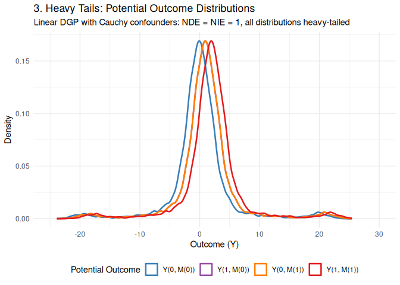

```r
plot_po_distributions(Y00, Y11, Y10, Y01,
  title = "3. Heavy Tails: Potential Outcome Distributions",
  subtitle = "Linear DGP with Cauchy confounders: NDE = NIE = 1, all distributions heavy-tailed",
  xlim = c(-25, 30))
```

## 4. Extreme Treatment Shifts (Extrapolation)

Engression maintains the structural relationship of the data better than many ML learners when shifting far outside the training range.

**Scenario**: Shift $A$ by +5 units (standard deviation is 1).

- $M = A + \epsilon_M$, $Y = M + \epsilon_Y$ (all indirect, no direct $A$ effect on $Y$)
- $d_0(A) = A$, $d_1(A) = A + 5$
- **True ATE = NIE**: $\mathbf{5.0}$, **True NDE**: $\mathbf{0.0}$

```r
set.seed(123)
n <- 1000
A <- rnorm(n)
M <- A + rnorm(n, 0, 0.5)
Y <- M + rnorm(n, 0, 0.5)
data <- data.frame(A, M, Y, W = rnorm(n))

d_extrap <- \(data, trt) data[[trt]] + 5

# dma
res_dma_extrap <- dma(
  data = data, trt = "A", outcome = "Y", mediators = "M", covar = "W",
  d0 = \(data, trt) data[[trt]],
  d1 = d_extrap, effect = "N",
  control = dma_control(crossfit_folds = 1L, num_epochs = 200L, riesz_epochs = 50L)
)

# crumble
res_crumble_extrap <- crumble(
  data = data, trt = "A", outcome = "Y", mediators = "M", covar = "W",
  d0 = \(data, trt) data[[trt]],
  d1 = d_extrap, effect = "N",
  learners = "glm",
  control = crumble_control(crossfit_folds = 1L, epochs = 20L)
)
```

| Estimand | Truth | dma | crumble (GLM) |
| --- | --- | --- | --- |
| ATE | 5.0 | 4.582 | 9.814 |

### Distributional decomposition

```r
set.seed(42)
n_o <- 10000
A_o <- rnorm(n_o)
eps_m <- rnorm(n_o, 0, 0.5)
eps_y <- rnorm(n_o, 0, 0.5)

# M under each regime
M_d0 <- A_o + eps_m           # d0: M(A)
M_d1 <- (A_o + 5) + eps_m     # d1: M(A+5)

# Y = M + eps_y (no direct A effect on Y)
Y00 <- M_d0 + eps_y   # Y(d0, M(d0))
Y11 <- M_d1 + eps_y   # Y(d1, M(d1))
Y10 <- M_d0 + eps_y   # Y(d1, M(d0)) = Y(d0, M(d0)) since no direct effect
Y01 <- M_d1 + eps_y   # Y(d0, M(d1)) = Y(d1, M(d1)) since no direct effect

knitr::kable(print_decomposition(Y00, Y11, Y10, Y01), align = "lr")
```

| Effect | Value |
| --- | --- |
| ATE = E[Y(1,M(1))] - E[Y(0,M(0))] | 5 |
| NDE = E[Y(1,M(0))] - E[Y(0,M(0))] | 0 |
| NIE = E[Y(1,M(1))] - E[Y(1,M(0))] | 5 |

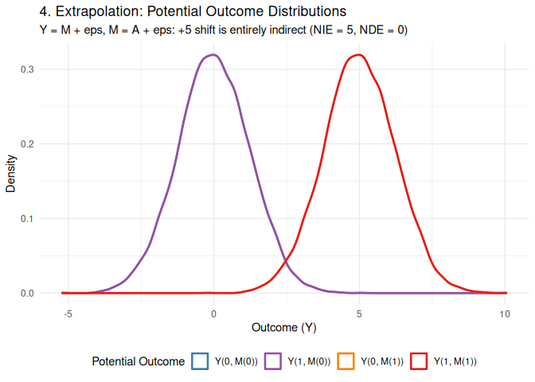

```r
plot_po_distributions(Y00, Y11, Y10, Y01,
  title = "4. Extrapolation: Potential Outcome Distributions",
  subtitle = "Y = M + eps, M = A + eps: +5 shift is entirely indirect (NIE = 5, NDE = 0)")
```

**Key insight**: The +5 shift moves the entire distribution by 5 units through the mediator. Since there’s no direct $A$ effect on $Y$, the NDE is zero and $Y(1,M(0)) = Y(0,M(0))$. The challenge is extrapolation: the shifted regime is 5 SDs outside training range. Engression preserves the linear structural relationship; crumble’s GLM nearly doubles the effect to 9.8.

## Summary

[output not shown]

The potential outcome distributions above show what mean-based estimates compress into a single number. In scenarios 1–2, the treatment operates *entirely* through the mediator ($\text{NDE} = 0$), but the mechanism is distributional — changing variance or modality rather than the mean. These are precisely the cases where `dma`’s distributional regression recovers effects that conditional-mean methods miss.

## References

- Liu, R., Williams, N., Rudolph, K., & Diaz, I. (2024). General Mediation Analysis. arXiv:2408.14620.
- Shen, X. & Meinshausen, N. (2024). Engression: Extrapolation through the Lens of Distributional Regression. *JMLR*.